# 화장품 논문 분석을 통한 트렌드 보고서

Author

waterfirst

```r
# 현재 년도 구하기
current_year <- as.numeric(format(Sys.Date(), "%Y"))
start_year <- current_year - 9

# PubMed 검색 및 데이터 추출 함수 (수정됨)
search_and_extract <- function(company, start_year) {
  query <- paste0('("', company, '"[Affiliation]) AND (cosmetics OR skincare OR "skin care" OR beauty OR dermatology) AND ("', start_year, '"[PDAT] : "', current_year, '"[PDAT])')
  search_result <- EUtilsSummary(query, type="esearch", db="pubmed", retmax=5000)
  articles <- EUtilsGet(search_result)

  years <- YearPubmed(articles)
  keywords <- Keywords(articles)

  # 키워드를 문자열로 결합
  keywords <- sapply(keywords, function(x) paste(x, collapse = ", "))

  # 데이터프레임 생성
  data.frame(
    PY = years,
    DE = keywords,
    stringsAsFactors = FALSE
  ) %>%
    mutate(PY = as.numeric(PY)) %>%
    filter(!is.na(PY) & PY >= start_year)
}

# 데이터 추출
shiseido_data <- search_and_extract("Shiseido", start_year)
loreal_data <- search_and_extract("L'Oreal", start_year)
cosmax_data <- search_and_extract("Cosmax", start_year)

# 키워드 트렌드 분석 함수
analyze_keyword_trends <- function(data, company_name) {
  yearly_keywords <- data %>%
    separate_rows(DE, sep = ", ") %>%
    mutate(DE = trimws(DE)) %>%
    filter(!is.na(DE) & DE != "" & DE != "NA") %>%
    mutate(DE = tolower(DE)) %>%
    group_by(PY, DE) %>%
    summarise(count = n(), .groups = 'drop') %>%
    arrange(PY, desc(count))

  top_keywords <- yearly_keywords %>%
    group_by(DE) %>%
    summarise(total_count = sum(count), .groups = 'drop') %>%
    top_n(3, total_count) %>%
    pull(DE)

  trend_data <- yearly_keywords %>%
    filter(DE %in% top_keywords)

  trend_plot <- ggplot(trend_data, aes(x = PY, y = count, color = DE)) +
    geom_line() +
    geom_point() +
    theme_minimal() +
    labs(title = paste(company_name, "- Top 3 Keyword Trends Over Time"),
         x = "Year", y = "Frequency",
         color = "Keyword") +
    theme(legend.position = "right")

  wordcloud_data <- yearly_keywords %>%
    group_by(DE) %>%
    summarise(count = sum(count), .groups = 'drop') %>%
    arrange(desc(count)) %>%
    head(100)

  wordcloud_plot <- wordcloud2(data = wordcloud_data,
                               size = 0.5,
                               shape = 'circle',
                               rotateRatio = 0,
                               minSize = 5,
                               color = colorRampPalette(brewer.pal(8, "Dark2"))(nrow(wordcloud_data)))




  return(list(trend_plot = trend_plot,
              wordcloud = wordcloud_plot,
              keyword_changes = trend_data))
}
```

```r
# 각 회사별 분석 실행
shiseido_analysis <- analyze_keyword_trends(shiseido_data, "Shiseido")
loreal_analysis <- analyze_keyword_trends(loreal_data, "L'Oreal")
cosmax_analysis <- analyze_keyword_trends(cosmax_data, "Cosmax")
```

```r
# 검색 함수 정의
search_company_papers <- function(company, start_year) {
  query <- paste0('("', company, '"[Affiliation]) AND (cosmetics OR skincare OR "skin care" OR beauty OR dermatology) AND ("', start_year, '"[PDAT] : "', current_year, '"[PDAT])')
  search_result <- EUtilsSummary(query, type="esearch", db="pubmed", retmax=5000)
  return(search_result)
}

# 연도별 논문 수 계산 함수 (수정됨)
get_yearly_counts <- function(search_result, start_year, end_year) {
  fetch_result <- EUtilsGet(search_result)
  years <- as.numeric(YearPubmed(fetch_result))
  year_counts <- table(factor(years, levels = start_year:end_year))
  return(as.vector(year_counts))
}


shiseido_search <- search_company_papers("Shiseido", start_year)
loreal_search <- search_company_papers("L'Oreal", start_year)
cosmax_search <- search_company_papers("Cosmax", start_year)

# 연도별 논문 수 계산 (수정됨)
shiseido_counts <- get_yearly_counts(shiseido_search, start_year, current_year)
loreal_counts <- get_yearly_counts(loreal_search, start_year, current_year)
cosmax_counts <- get_yearly_counts(cosmax_search, start_year, current_year)
```

## 1. 서론

본 보고서는 시세이도와 로레알, 두 글로벌 화장품 기업의 최근 10년간 연구 논문을 분석하여 화장품 산업의 트렌드를 파악하고, 이를 바탕으로 대한민국 화장품 회사들의 향후 연구개발 전략을 제시하고자 합니다.

## 2. 데이터 개요

- 분석 기간: 2015년부터 2024년까지
- 데이터 소스: PubMed
- 분석 대상 기업: 시세이도, 로레알, 코스맥스

### 2.1 논문 수 비교

```r
data.frame(
  Company = c("시세이도", "로레알", "코스맥스"),
  Papers = c(nrow(shiseido_data), nrow(loreal_data), nrow(cosmax_data))
) %>%
  kable() %>%
  kable_styling(full_width = FALSE)
```

| Company | Papers |
| --- | --- |
| 시세이도 \| | 101\| |
| 로레알 \| | 306\| |
| 코스맥스 \| | 40\| |

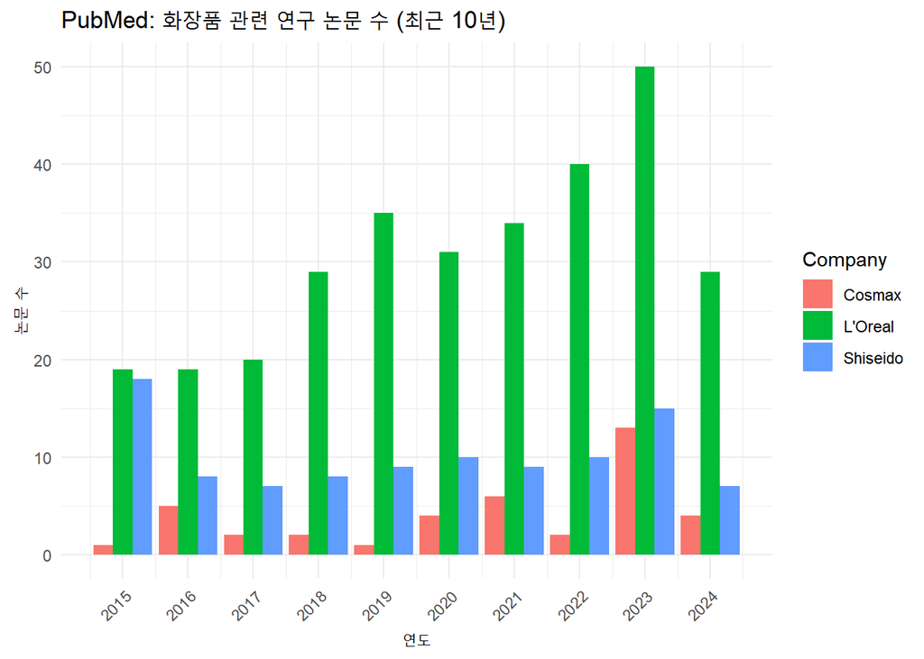

```r
# PubMed 검색 결과 그래프 생성
plot_data <- data.frame(
  Year = rep(start_year:current_year, 3),
  Count = c(shiseido_counts, loreal_counts, cosmax_counts),
  Company = rep(c("Shiseido", "L'Oreal", "Cosmax"), each = length(start_year:current_year))
)

p_pubmed <- ggplot(plot_data, aes(x = Year, y = Count, fill = Company)) +
  geom_bar(stat = "identity", position = "dodge") +
  theme_minimal() +
  labs(title = "PubMed: 화장품 관련 연구 논문 수 (최근 10년)",
       x = "연도", y = "논문 수") +
  scale_x_continuous(breaks = start_year:current_year) +
  theme(axis.text.x = element_text(angle = 45, hjust = 1))
p_pubmed
```

## 3. 키워드 트렌드 분석

### 3.1 키워드 트렌드 그래프

#### 시세이도

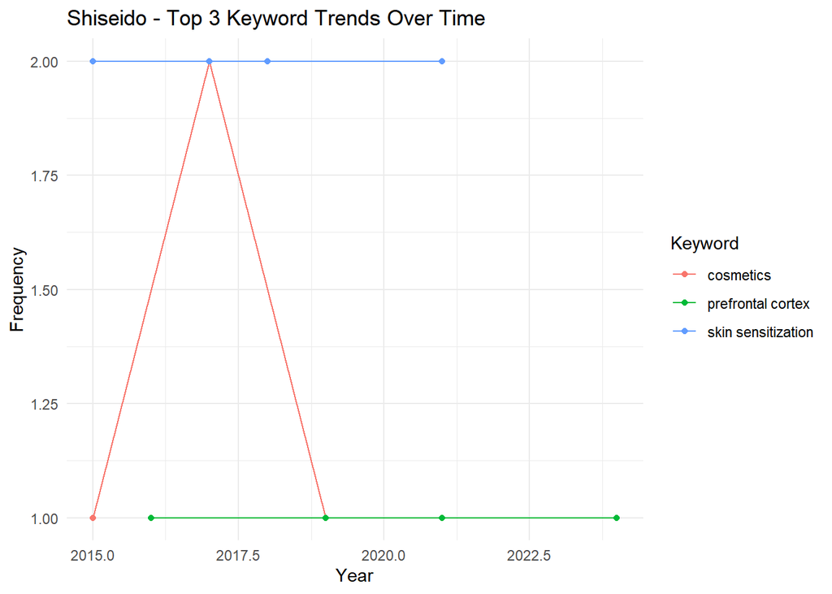

```r
shiseido_analysis$trend_plot
```

#### 로레얄

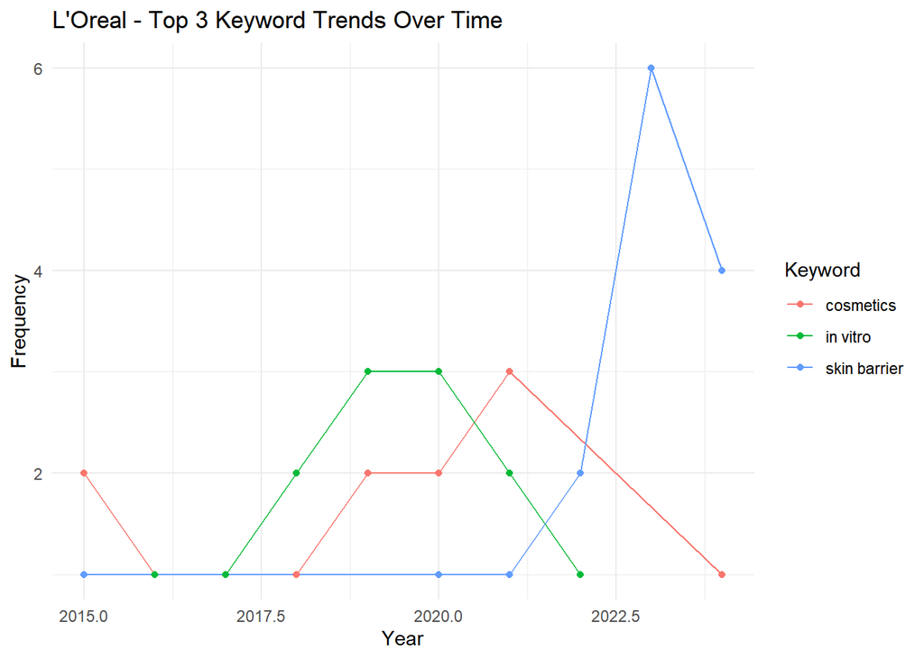

```r
loreal_analysis$trend_plot
```

#### 코스맥스

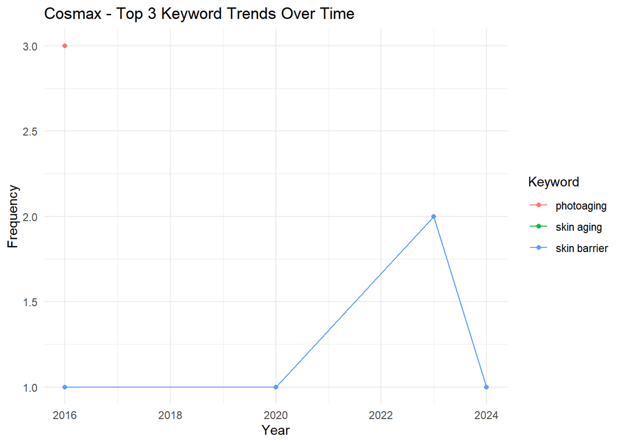

```r
cosmax_analysis$trend_plot
```

### 3.2 워드클라우드

#### 시세이도

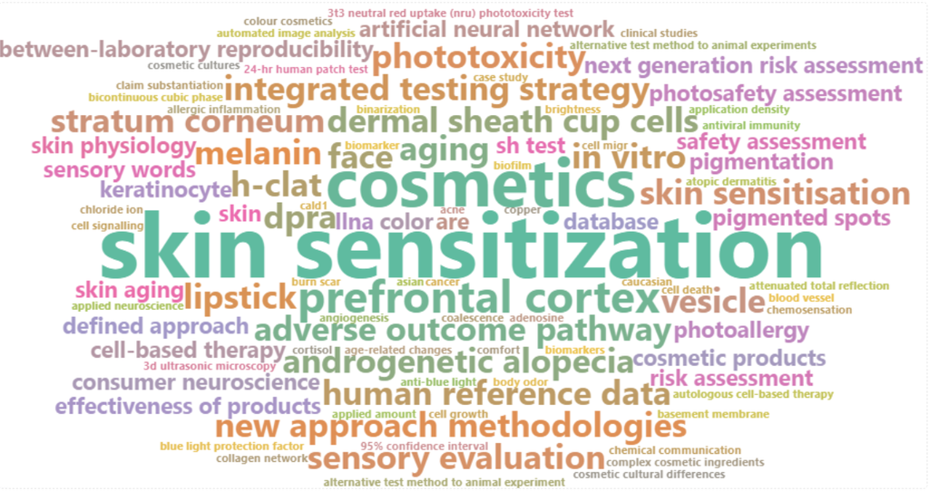

#### 로레얄

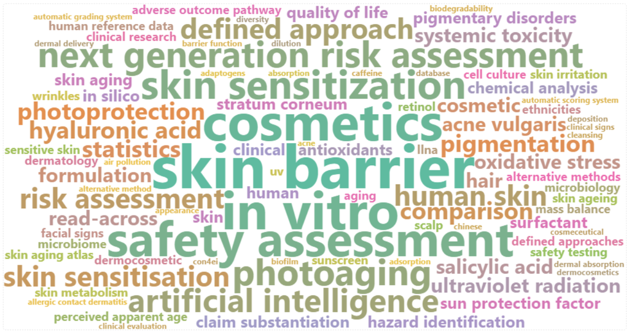